# Library Analysis

Amber Thomas

Last updated: May 23, 2019

## Introduction

Russell and I are working together to answer several questions about the way that people utilize libraries, specifically, the Seattle Public library. The SPL has lots of [open data](https://data.seattle.gov/Community/Integrated-Library-System-ILS-Data-Dictionary/pbt3-ytbc), including their [full catalog of items](https://data.seattle.gov/Community/Library-Collection-Inventory/6vkj-f5xf) (2017 - 2019, monthly), and all [checkouts of physical items](https://data.seattle.gov/Community/Checkouts-By-Title-Data-Lens/5src-czff) (2005 - 2019).

Here are a few of the questions that we hope to answer:

- How much of our knowledge is being forgotten (i.e., how many days has it been since each item has been checked out?)
- What books are/aren’t getting love (i.e., is this like wealth distribution where 99% of the love goes to 1% of the books?)

### Load Packages

I’ll import the packages that I need:

```r
# For general data cleaning and analysis
library(tidyverse)
library(glue)

# For keeping your files in relative directories
library(here)

# For interactive/searchable tables in your report
library(DT)

# For dealing with very large datasets locally
library(data.table)

# For dealing with dates
library(lubridate)

# For Pudding-related convenience functions
library(puddingR)

# For handling big file filtered imports
library(sqldf)
```

### Load Data

Because the data file is large, I’m going to use the `fread` function from `data.table`.

```r
filePath <- here::here("assets", "data", "raw_data", "checkouts--books-small.csv")

# download from local file
checkouts <- data.table::fread(filePath) %>%
  # convert checkoutdatetime to a date object
  mutate(date = mdy(CheckoutDateTime)) %>%
  select(-CheckoutDateTime)
```

## Data Exploration

Now to start exploring and analyzing the data

### Days Since Checkout

Let’s see if I can get to the first question at hand: how many days has it been since each book has been checked out last?

First, I need to know the latest date in the dataset:

```r
max <- checkouts %>%
  arrange(desc(date)) %>%
  slice(1)

maxDate <- max$date
```

For the record, it was 2019-05-14. Now, we’ll go through and programmatically calculate the time between that date the last time each item was checked out.

```r
# Calculate time between last checkout and May 14, 2019
last <- checkouts %>%
  # group by bibliographic number and arrange by descending date
  group_by(BibNumber) %>%
  arrange(desc(date)) %>%
  # keep only the most recent date
  slice(1) %>%
  ungroup() %>%
  # calculate the length of time between the max date and the date listed for each checkout
  # this includes leap years and other time anomalies
  rowwise() %>%
  mutate(
    daysSinceCheckout = lubridate::time_length(interval(
      start = date,
      end = maxDate
    ), "days")
  )
```

For safe keeping, let’s write that to a csv file in the `processed_data` directory.

```r
# write last to file
outputLast <- here::here("assets", "data", "processed_data")
puddingR::export_data(last, "last_checkout", directory = outputLast)
```

Can we make a histogram of these?

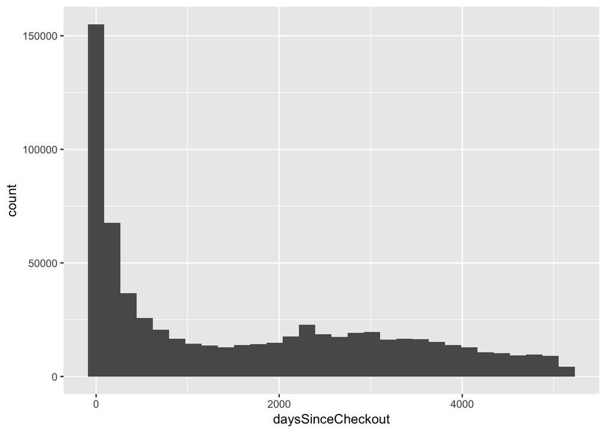

```r
ggplot(last, aes(x = daysSinceCheckout)) + geom_histogram()
```

Wow, so according to this, 19.6760351% of books have been checked out in the last 60 days.

How many haven’t been checked out in the past year?

```r
# calculate books that haven't been checked out in at least 365 days
pastYear <- last %>%
  filter(daysSinceCheckout > 365) %>%
  count(.)

# calculate the percentage of books that meet the above criteria
yearPercent <- (pastYear$n / nrow(last) * 100)
yearPercent
```

```
## [1] 63.24301
```

Ouch, 63.2430142%?!

How many were checked out the day we ran the data?

```r
zero <- last %>%
  filter(daysSinceCheckout == 0)
```

9769

### Quantity of Checkouts

Now that we have an idea of how often books are checked out, we can look at how many times a book has been checked out.

```r
# Calculate the number of times each item has been checked out
quant <- checkouts %>%
  # Count the number of checkouts per BibNumber
  group_by(BibNumber) %>%
  summarise(count = n()) %>%
  # remove WiFi logins
  filter(BibNumber != "3030520")
```

And save it to a file

```r
# write quant to file
outputQuant <- here::here("assets", "data", "processed_data")
puddingR::export_data(quant, "checkout_quantity", directory = outputQuant)
```

Now to checkout the histogram of checkout counts

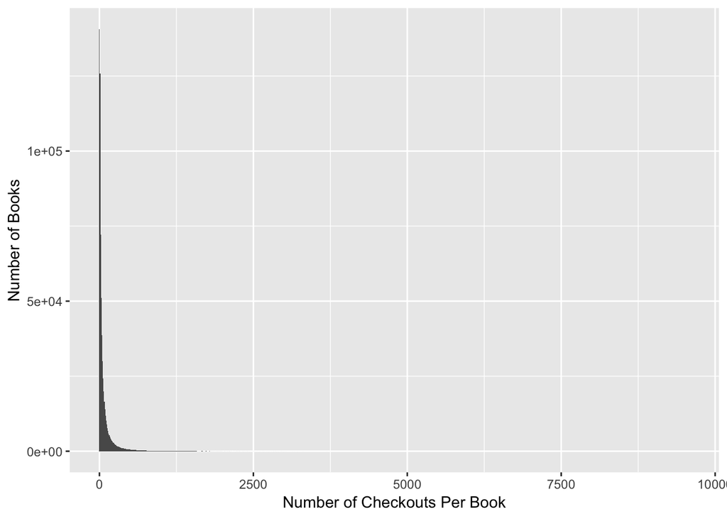

```r
ggplot(quant, aes(x = count)) + geom_histogram(binwidth = 10) +
  ylab("Number of Books") +
  xlab("Number of Checkouts Per Book")
```

Hmm let’s try looking at this another way. Calculating it like income distribution:

```r
# Calculating bins
bins <- quant %>%
  # Break up data into 100 bins based on checkout number
  mutate(bin = ntile(count, 100))

# Find average per bin
distribution <- bins %>%
  group_by(bin) %>%
  summarise(average = round(mean(count)))
```

And plot the distribution

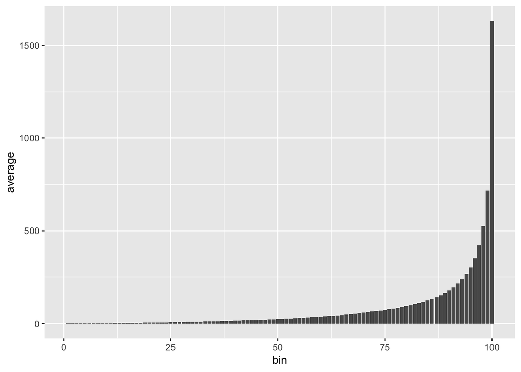

```r
ggplot(distribution, aes(x = bin, y = average)) + geom_bar(stat = "identity")
```

What percentage of checkouts are attributed to the most checked out 1% of books?

```r
# Find total number of book checkouts across all books
totalCheckouts <- bins %>%
  summarise(sum = sum(count))

# Find total number of checkouts from just the 1% of most checked-out books
one_percent <- bins %>%
  filter(bin == 100) %>%
  summarise(sum = sum(count))
```

Looks like 20% of checkouts come from the top 1% of most checked out books.

How about top 5%?

```r
# Find total number of checkouts from just the 1% of most checked-out books
five_percent <- bins %>%
  filter(bin > 95) %>%
  summarise(sum = sum(count))
```

A full 45% of checkouts come from the most popular 5% of books!

### Lag Time Between Checkouts

How much time goes by between a book being checked out and placed back on the shelf? I’ll calculate median lag time between checkouts per book

```r
sub <- lagtime %>% filter(BibNumber %in% c("2455046", "2444236", "2378434"))
lagtime <- checkouts %>%
  group_by(BibNumber) %>%
  arrange(date) %>%
  mutate(timeSinceLast = date - lag(date))

outputLagSum <- here::here("assets", "data", "processed_data", "checkouts_lag_sum.csv")

lagSum <- lagtime %>%
  group_by(BibNumber) %>%
  filter(!is.na(timeSinceLast)) %>%
  summarise(median = median(timeSinceLast),
            mean = mean(timeSinceLast)) %>%
  fwrite(., file = outputLagSum)
```

```r
# write lagtime to file
outputLag <- here::here("assets", "data", "processed_data", "checkout_lagtime.csv")
fwrite(lagtime, file = outputLag)
#puddingR::export_data(lagtime, "checkout_lagtime", directory = outputLag)
```

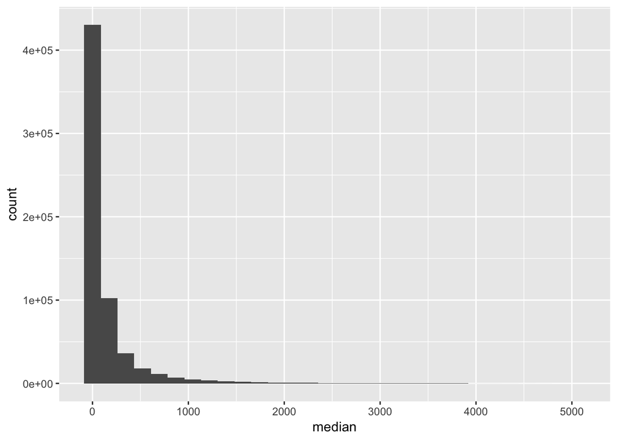

```r
ggplot(lagSum, aes(x = median)) + geom_histogram()
```

How many books have a median lag time between checkouts of less than 30 days?

```r
under30 <- lagSum %>%
  filter(median <= 30)
```

Huh, 48% of books are checked out at least once a month.

What percentage are checked out at least once a year (on average)?

```r
under365 <- lagSum %>%
  filter(median <= 365)
```

Wow, a full 89% of books are (on average) checked out at least once a year.

### Catalog

To add more detail to the above data, I’m going to import the library’s full catalog.

```r
catalog <- fread(here::here("assets", "data", "raw_data", "inventory--books.csv"))
```

The full catalog is huge, so let’s try to import just the bits we need.

```r
# use here to find the file you want and save the file path to a variable
file_path <- here::here("assets", "data", "raw_data", "book_codes.csv")

# from csv
filter <- readr::read_csv(file_path) %>%
  dplyr::rename("group" = "Category Group", "code" = "Code", "description" = "Description")

# create a character vector of just the code values
code <- filter$code
```

```r
# list the location of the entire inventory file
inventoryLoc <- here::here("assets", "data", "raw_data", "inventory.csv")

# import file and filter only the columns we want
invCol <- c("numeric", "character", "character", "character", "character", "NULL", "character", "character", "character", "NULL", "NULL", "character", "numeric" )

catalogCheck <- fread(inventoryLoc,
                      header = TRUE,
                      colClasses = invCol)

# Filter the catalog to just the parts we need
catalogFilter <- catalogCheck %>%
  # Keep only the items whose ItemCollection are in the "code" file
  filter(ItemCollection %in% code) %>%
  # count the total number of copies of each book at each report date
  group_by(ReportDate, BibNum) %>%
  mutate(totalCopies = sum(ItemCount)) %>%
  # Keep only one entry per item per report date
  group_by(ReportDate) %>%
  distinct(BibNum, .keep_all = TRUE) %>%
  # Write to file
  fwrite(., here::here("assets", "data", "processed_data", "inventory_books_copies.csv"))
```

Alright, so I need to make a few adjustments to trim down the size of this catalog. For each report date, I need a sum of copies of each book for each inventory report date. Then, I also need to find the earliest and latest dates that each item was in the library’s inventory.

```r
# Import the file if necessary
catalogFilter <- fread(here::here("assets", "data", "processed_data", "inventory_books_copies.csv"))

# Further reduce the data
catalogMinimal <- catalogFilter %>%
  # conver the date to a date object
  mutate(date = mdy(ReportDate)) %>%
  # Arrange item entries by report date
  # Noting only the earliest and latest reports of each item
  group_by(BibNum) %>%
  arrange(date) %>%
  mutate(maxDate = max(date),
         minDate = min(date),
         maxCopies = max(totalCopies)) %>%
  # Keep only one entry of each item
  distinct(BibNum, .keep_all = TRUE) %>%
  # Remove unneccessary columns
  select(-c("ReportDate", "ItemCount", "totalCopies", "date")) %>%
  fwrite(., here::here("assets", "data", "processed_data", "inventory_minimal.csv"))
```

So, strangely, I’m seeing 665566 unique items that have been checked out at least once in the past 14 years, but only 402267 unique items in the catalog. It is possible that there are 263299 items that used to be in the inventory at some point and aren’t now? Let’s look into the items that are missing. I’ll use an `anti_join`.

```r
missingCat <- last %>%
  anti_join(catalogMinimal, by = c("BibNumber" = "BibNum"))

sample <- head(missingCat, n = 1000)
```

Huh…that’s quite a lot of books. I’ll have to follow up with the library about this.

### Top Books

Let’s find which books are the most common to check out

```r
topBooks <- checkouts %>%
  count(BibNumber, sort = TRUE)
```

```r
topPath <- here::here("assets", "data", "processed_data", "top_books.csv")
fwrite(topBooks, topPath)
```

| BibNumber | n |
| --- | --- |
| 3030520 | 27003 |
| 135501 | 9582 |
| 1126205 | 9359 |
| 2550250 | 9056 |
| 2107139 | 8912 |
| 2452011 | 8904 |
| 545653 | 8827 |
| 101004 | 8819 |
| 2617596 | 8562 |
| 2419221 | 8488 |

[output cut: 10 more lines]